# Data Lab 3 Working with Areal Data

# 3.1 Working with Spatial Polygons

We will first load a standard data frame consists of several county-level variables:

```r
setwd ("H:/Teaching/Bios737 Spatial Analysis/2025 SISMID/Module 3")
load ("Data.RData")
summary (dat)
```

```
##      FIPS                        Area     State      Population
##  Length:226         Baldwin County :  2   AL: 67   Min.   :  1884
##  Class :character   Bibb County    :  2   GA:159   1st Qu.: 13321
##  Mode  :character   Calhoun County :  2            Median : 24790
##                     Cherokee County:  2            Mean   : 62711
##                     Clarke County  :  2            3rd Qu.: 61807
##                     Clay County    :  2            Max.   :992137
##                     (Other)        :214
##      Cases            Income           inc
##  Min.   :   6.0   Min.   :16646   Min.   :  5.00
##  1st Qu.:  48.0   1st Qu.:27477   1st Qu.: 25.00
##  Median :  91.0   Median :31186   Median : 41.00
##  Mean   : 299.3   Mean   :33255   Mean   : 45.88
##  3rd Qu.: 223.8   3rd Qu.:36738   3rd Qu.: 61.00
##  Max.   :6139.0   Max.   :71227   Max.   :131.00
##
```

Next, we will read in county spatial polygons for the contiguous US in the *maps* package. R can also read in any shapefile via the *sf* package. The *st_as_sf* function converts the map object to an *sf* object, which encodes the ID, polygons, and any unit-specific data value.

```r
library (sf)
```

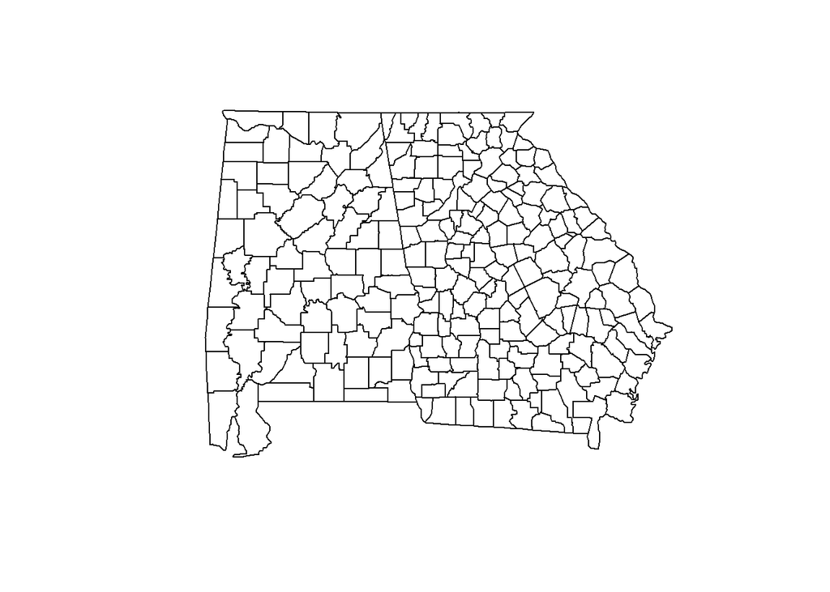

```r
library (maps)

county.map = map ("county", region = c("alabama", "georgia"),fill = T,  plot = F)
county.map = sf::st_as_sf(county.map) #Convert from map object to sf

plot (st_geometry(county.map)) #only plot the polygons
```

Our sf object contains several attributes:

- $ID = county identifier string
- $geom:sfc_MULTIPOLYGON = sets of polygons (n = 226)

```r
str (county.map)
```

```
## Classes 'sf' and 'data.frame':   226 obs. of  2 variables:
##  $ ID  : chr  "alabama,autauga" "alabama,baldwin" "alabama,barbour" "alabama,bibb" ...
##  $ geom:sfc_MULTIPOLYGON of length 226; first list element: List of 1
##   ..$ :List of 1
##   .. ..$ : num [1:51, 1:2] -86.5 -86.5 -86.5 -86.6 -86.6 ...
##   ..- attr(*, "class")= chr [1:3] "XY" "MULTIPOLYGON" "sfg"
##  - attr(*, "sf_column")= chr "geom"
##  - attr(*, "agr")= Factor w/ 3 levels "constant","aggregate",..: NA
##   ..- attr(*, "names")= chr "ID"
```

```r
attributes (county.map)
```

```
## $names
## [1] "ID"   "geom"
##
## $row.names
##   [1] "alabama,autauga"       "alabama,baldwin"       "alabama,barbour"
##   [4] "alabama,bibb"          "alabama,blount"        "alabama,bullock"
##   [7] "alabama,butler"        "alabama,calhoun"       "alabama,chambers"
##  [10] "alabama,cherokee"      "alabama,chilton"       "alabama,choctaw"
##  [13] "alabama,clarke"        "alabama,clay"          "alabama,cleburne"
##  [16] "alabama,coffee"        "alabama,colbert"       "alabama,conecuh"
##  [19] "alabama,coosa"         "alabama,covington"     "alabama,crenshaw"
##  [22] "alabama,cullman"       "alabama,dale"          "alabama,dallas"
##  [25] "alabama,de kalb"       "alabama,elmore"        "alabama,escambia"
##  [28] "alabama,etowah"        "alabama,fayette"       "alabama,franklin"
##  [31] "alabama,geneva"        "alabama,greene"        "alabama,hale"
```

[output cut: 76 more lines]

Let’s look some meta data information:

- In GIS terminology, each polygon is called a feature.
- Dimension: XY means the feature is 2-dimensional
- Bounding box: the max/min used for plotting
- Geodetic CRS: the projection/datum

```r
print (county.map, n = 2)
```

```
## Simple feature collection with 226 features and 1 field
## Geometry type: MULTIPOLYGON
## Dimension:     XY
## Bounding box:  xmin: -88.47614 ymin: 30.24071 xmax: -80.84435 ymax: 35.01345
## Geodetic CRS:  +proj=longlat +ellps=clrk66 +no_defs +type=crs
## First 2 features:
##                              ID                           geom
## alabama,autauga alabama,autauga MULTIPOLYGON (((-86.50517 3...
## alabama,baldwin alabama,baldwin MULTIPOLYGON (((-87.93757 3...
```

There are several ways we can extract information from an sf object.

```r
#Extract the first polygon and make a plot
poly1 = st_geometry (county.map)[[1]]

#Print all the points used to draw the polygon
poly1
```

```
## MULTIPOLYGON (((-86.50517 32.3492, -86.53382 32.35493, -86.54527 32.36639, -86.55673 32.37785, -86.57966 32.38357, -86.59111 32.37785, -86.61403 32.38931, -86.61976 32.40649, -86.62549 32.41795, -86.63695 32.41795, -86.65414 32.41222, -86.65987 32.38931, -86.67133 32.36639, -86.68279 32.36639, -8…
```

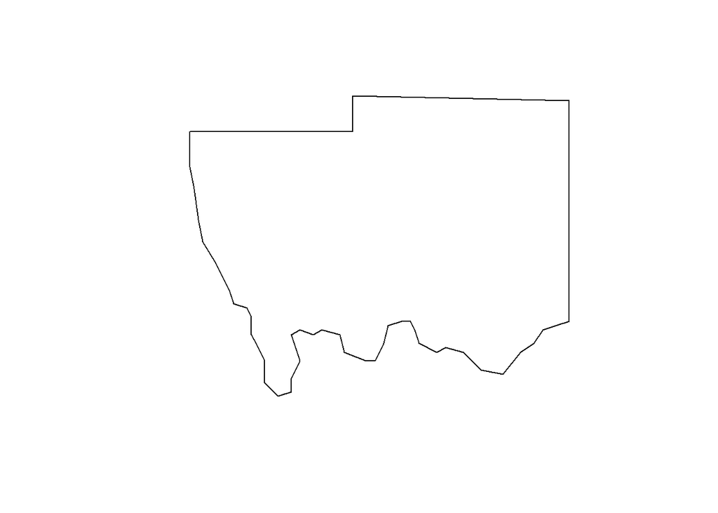

```r
plot (poly1)
```

Our first data task is to merge the dataset with the sf object. In our case, the counties are ordered by row exactly the same for the two datasets and we can use *cbind*. In general, it’s good to merge by polygon ID.

```r
#Option 1
dat.areal = cbind (county.map, dat)
dat.areal[1:3,]
```

```
## Simple feature collection with 3 features and 8 fields
## Geometry type: MULTIPOLYGON
## Dimension:     XY
## Bounding box:  xmin: -88.01778 ymin: 30.24071 xmax: -85.06131 ymax: 32.71016
## Geodetic CRS:  +proj=longlat +ellps=clrk66 +no_defs +type=crs
##                              ID  FIPS           Area State Population Cases
## alabama,autauga alabama,autauga 01001 Autauga County    AL      49960   184
## alabama,baldwin alabama,baldwin 01003 Baldwin County    AL     171769   416
## alabama,barbour alabama,barbour 01005 Barbour County    AL      27941   165
##                 Income inc                           geom
## alabama,autauga  42013  37 MULTIPOLYGON (((-86.50517 3...
## alabama,baldwin  40250  24 MULTIPOLYGON (((-87.93757 3...
## alabama,barbour  25101  59 MULTIPOLYGON (((-85.42801 3...
```

```r
#Option 2
library (stringr)
data (county.fips) #Load county 5-digit FIPS code
county.map$FIPS = county.fips$fips[ match (county.map$ID, county.fips$polyname)]
county.map$FIPS =  str_pad (county.map$FIPS, 5, "left", "0")
all (county.map$FIPS %in% dat$FIPS)
```

```
## [1] TRUE
```

```r
dat.areal2 = merge (county.map, dat, by = "FIPS")
```

The object *dat.areal*$* now contains the polygon information and the dataframe we would like to. We can do standard operations on the dataframe now. We can also create chloropleth map!

```r
dim (dat.areal)
```

```
## [1] 226   9
```

```r
names(dat.areal)
```

```
## [1] "ID"         "FIPS"       "Area"       "State"      "Population"
## [6] "Cases"      "Income"     "inc"        "geom"
```

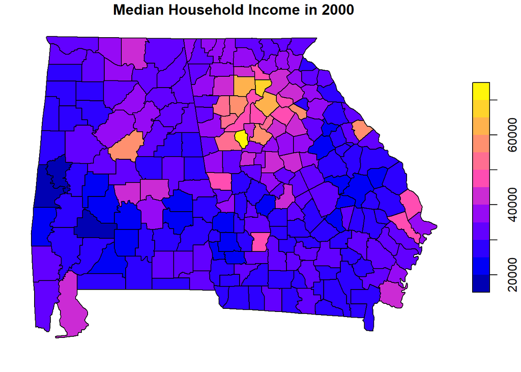

```r
library(colorRamps)
plot (dat.areal["Income"], main = "Median Household Income in 2000")
```

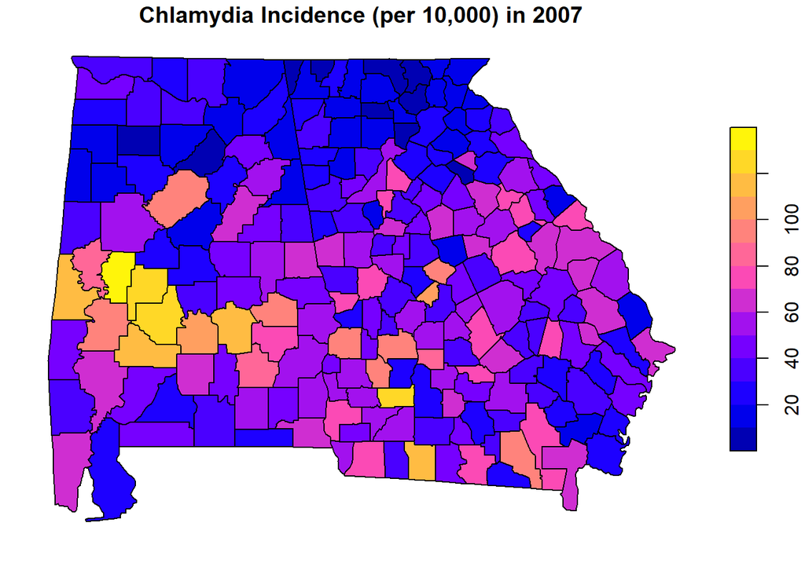

```r
plot (dat.areal["inc"],  main = "Chlamydia Incidence (per 10,000) in 2007")
```

Or use ggplot.

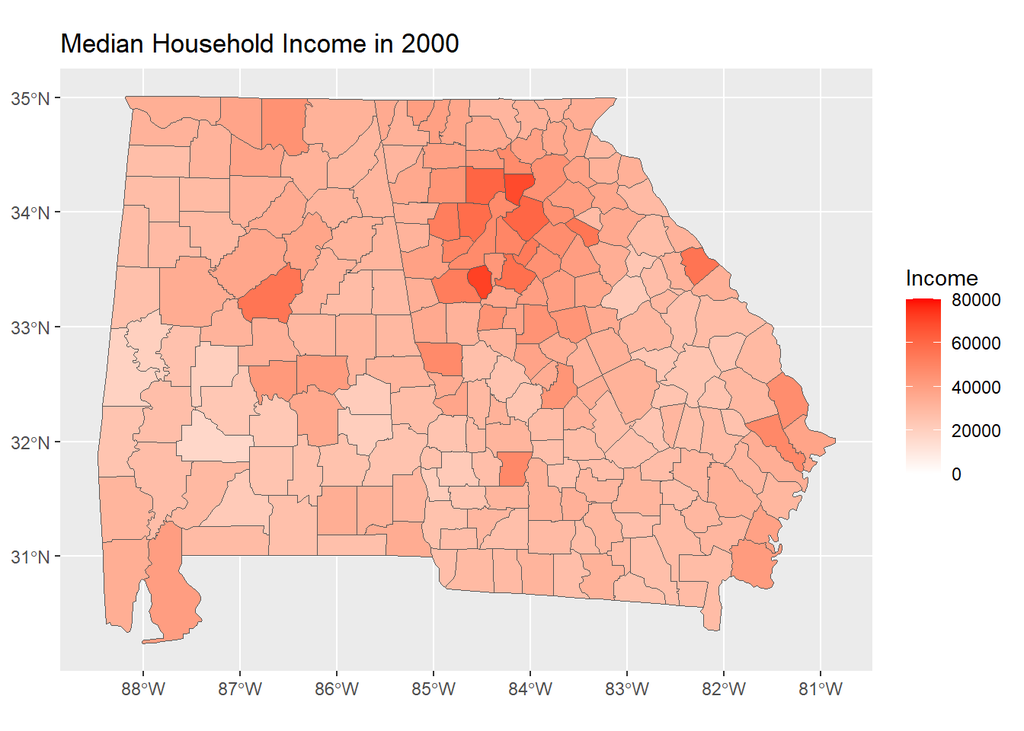

```r
library (ggplot2)
ggplot() + geom_sf (data = dat.areal, aes (fill = Income))+
  labs(title="Median Household Income in 2000")   +scale_fill_gradient2(low = "white",high = "red", limits = c(0, 80000))
```

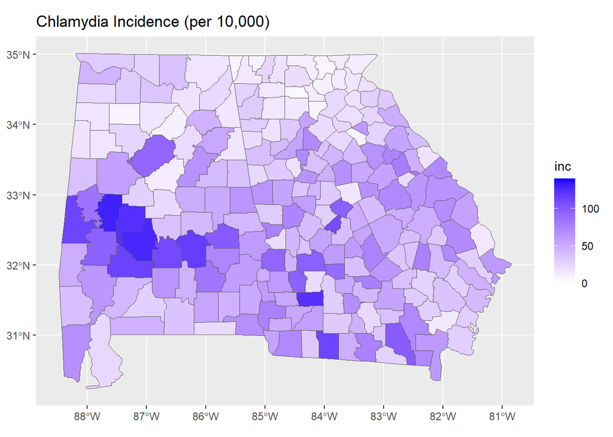

```r
ggplot() +  geom_sf (data = dat.areal, aes (fill = inc))+
  labs(title="Chlamydia Incidence (per 10,000)")  +scale_fill_gradient2(low = "white",high = "blue", limits = c(0, 140))
```

# 3.2 Defining Spatial Proximity

The package *spdep ()* contains a suite of functions for working with areal spatial data. The *poly2nb ()* function identifies neighbours using a spatial polygons. Neighbours are defined as sharing a common boundary point.The default in poly2nb uses the queen’s case definition that is two polygons are neighbours even if they share a single boundary. This can be suppressed by the *queen =* option.

```r
library (spdep)
```

[output not shown]

```
## To access larger datasets in this package, install the spDataLarge
## package with: `install.packages('spDataLarge',
## repos='https://nowosad.github.io/drat/', type='source')`
```

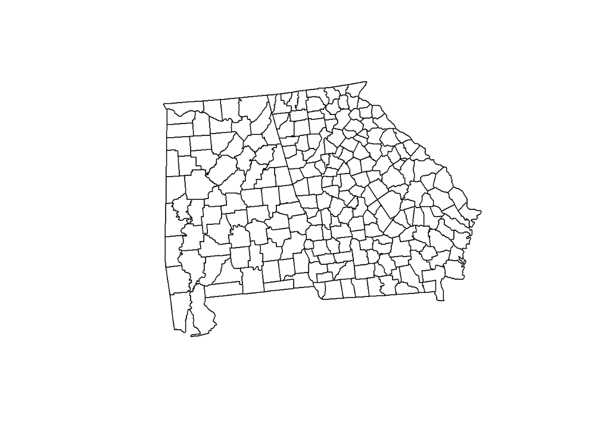

```r
#Because our shapefile here is un-projected, distance operations can be difficult. Alternatively, we can project the data to, for example, the Lambert Conformal Conic North America.
dat.areal_proj = st_transform(dat.areal, crs = "ESRI:102004")
plot (st_geometry(dat.areal_proj))
```

```r
nb = poly2nb (dat.areal_proj)
nb2 = poly2nb (dat.areal_proj, queen=FALSE)

#A lot of good summaries about the neighbor structure
summary (nb)
```

```
## Neighbour list object:
## Number of regions: 226
## Number of nonzero links: 1258
## Percentage nonzero weights: 2.462996
## Average number of links: 5.566372
## Link number distribution:
##
##  2  3  4  5  6  7  8  9 10
##  3 12 37 50 70 41  8  3  2
## 3 least connected regions:
## georgia,catoosa georgia,chatham georgia,rabun with 2 links
## 2 most connected regions:
## georgia,emanuel georgia,fulton with 10 links
```

The function *nb2mat ()* then creats a proximity/weight matrix using the neighbourhood information. Here we have several options to define weights:

- B: basic binary
- W: row standardized (sum of all entries = n)

```r
W = nb2mat (nb, style = "B")
center_proj = st_centroid(dat.areal_proj) ##Extract centroids of polygons
```

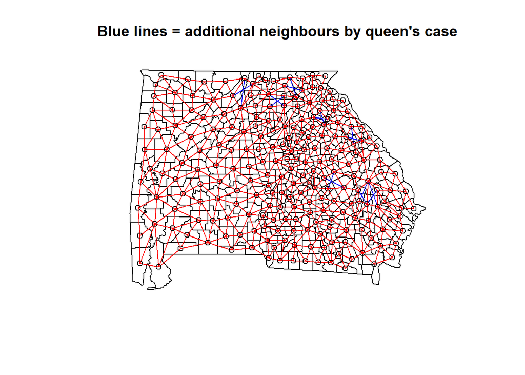

```r
center = st_transform(center_proj, crs = 4326) #Re-project back to WGS 84
center = st_coordinates (center)

plot (st_geometry(dat.areal))
plot (nb, center, add = TRUE, col = "blue")
plot (nb2, center, add = TRUE, col = "red", lwd = 1)
title (main="Blue lines = additional neighbours by queen's case")
```

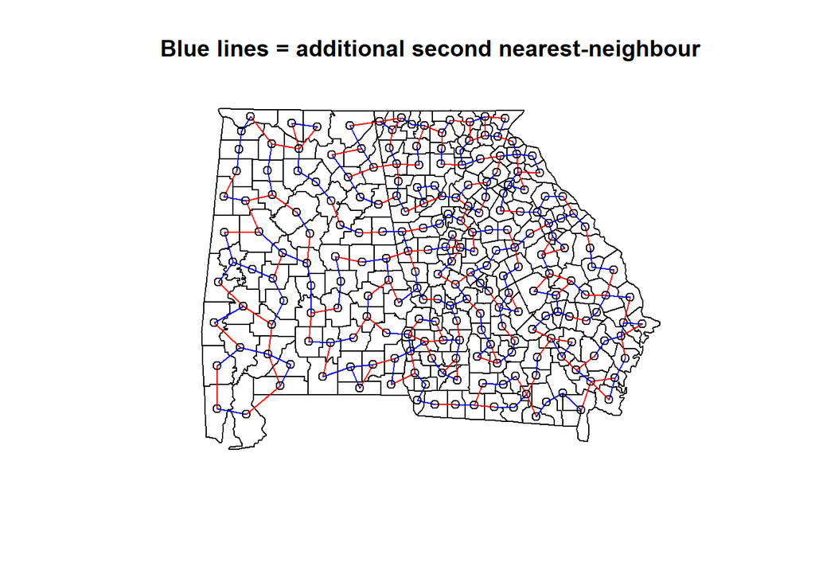

```r
## Using kth-nearest distance
nb.k1 = knn2nb (knearneigh(center_proj,k=1))
nb.k2 = knn2nb (knearneigh(center_proj,k=2), row.names=row.names(center))

plot (st_geometry(dat.areal))
plot (nb.k2, center, add = TRUE, col = "red", lwd = 1)
plot (nb.k1, center, add = TRUE, col = "blue", lwd = 1)
title (main="Blue lines = additional second nearest-neighbour")
```

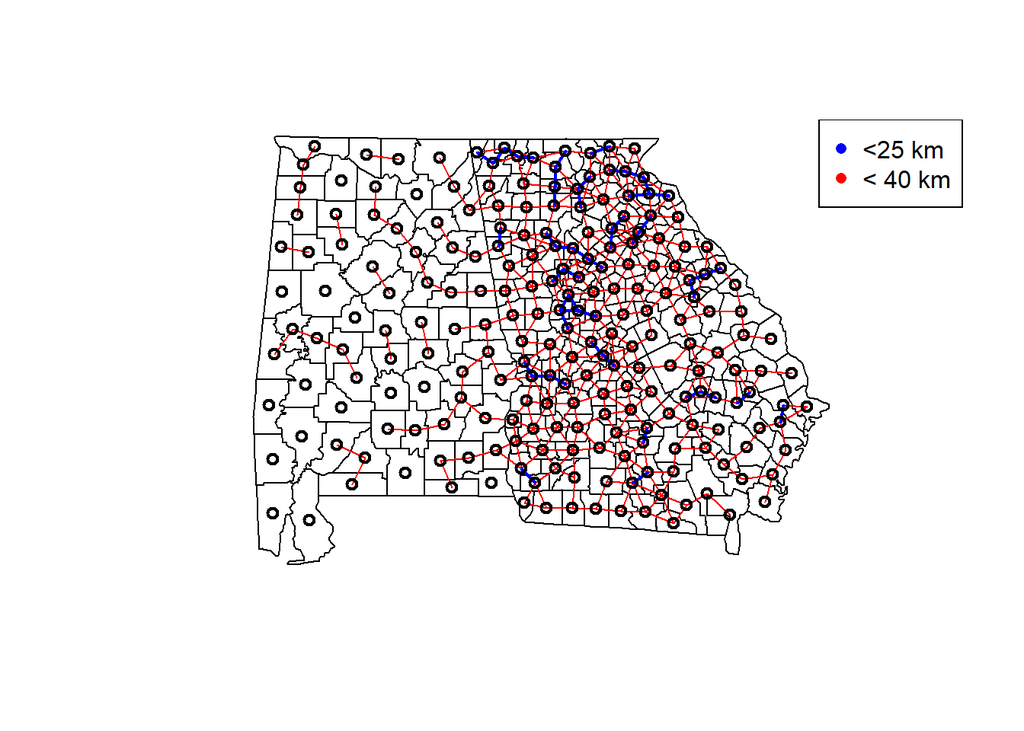

```r
## Using buffer distance
nb.buffer1 = dnearneigh(center_proj, d1=0, d2 = 25*1000)
nb.buffer2 = dnearneigh(center_proj, d1=0, d2 = 40*1000)

plot (st_geometry(dat.areal))
plot (nb.buffer2, center, add = TRUE, col = "red", lwd = 1)
plot (nb.buffer1, center, add = TRUE, col = "blue", lwd =2)
legend ("topright", legend =c("<25 km", "< 40 km"), col= c("blue", "red"), pch = 16)
```